# TP2 Linear Models

A.V Hurtado Quiceno

2/5/2023

install.packages(c(“ggplot2”, “dplyr”, “ISwR”, “MASS”, “Sleuth3”, “rmarkdown”, “tidyr”))

# Introduction Ozone Data

$\textbf{Objective:}$ L’objective est d’expliquer la variable `max03` par rapport a `T12` dans le modele lineare et par rapport a dans le modele multiple et faire un comparison avec le deux.

Le 5 premier colonnes de la data frame Ozone

| date | maxO3 | T6 | T9 | T12 | T15 | T18 | Ne6 | Ne9 | Ne12 | Ne15 | Ne18 | Vx | maxO3v |
| --- | --- | --- | --- | --- | --- | --- | --- | --- | --- | --- | --- | --- | --- |
| 19940401 | 56.0 | 8.6 | 9.5 | 6.8 | 9.1 | 7.7 | 6 | 3 | 6 | 7 | 4 | -10.8329 | 59.6 |
| 19940402 | 39.2 | 3.6 | 5.6 | 9.2 | 8.4 | 4.9 | 3 | 4 | 6 | 7 | 7 | -10.3366 | 56.0 |
| 19940403 | 36.0 | 2.7 | 7.3 | 6.3 | 7.0 | 7.9 | 6 | 8 | 8 | 8 | 8 | -1.0419 | 39.2 |
| 19940404 | 41.2 | 11.8 | 11.8 | 11.0 | 7.0 | 7.7 | 8 | 7 | 6 | 7 | 3 | -10.3366 | 36.0 |
| 19940405 | 27.6 | 3.7 | 8.3 | 11.6 | 10.7 | 7.9 | 6 | 3 | 6 | 6 | 6 | -8.8633 | 41.2 |

ou les varaibles sont:

- `obs`: mois-jour
- `maxO3`: teneur maximale en ozone observée sur la journée (en $\mu g r / m 3)$;
- `T6`, .. ,`T18`: température observée à $6 \mathrm{~h}, \ldots 18 \mathrm{~h}$;
- `Ne6`, .., `Ne18`: nébulosité observée à $6 \mathrm{~h}, \ldots, 18 \mathrm{~h}$;
- `$\mathrm{Vx}$`: composante est-ouest du vent ;
- `maxO3v`: teneur maximale en ozone observée la veille ;
- `vent`: orientation du vent à $12 \mathrm{~h}$;
- `pluie`: occurrence ou non de précipitations.

# Modèle linear simple $\mathcal{M}_{1}$ avec la varialble `T12`

On considére el modèle lineaire simple $\mathcal{M}_{1}$ avec la variable explicative `T12`.

$$\begin{equation}
(\mathcal{M}_{1}): max03= \beta_{0} + \beta_{1} T12 + \epsilon_{1}
\end{equation}$$

## Résumé

### Plot

[figure not shown]

### Scatter plot

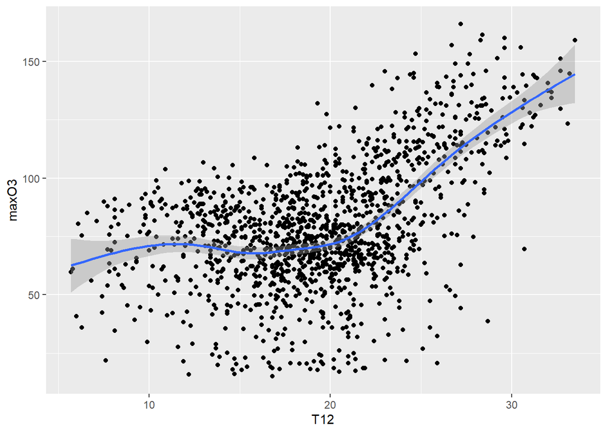

### Correlation

Ici on etude la correlation entre les deux variables `T12` et `maxo3`, on a que le valuer est $0.492$ i.e que on peut expliquer la variable `maxo3` par la variable `T12`

```
## [1] 0.4922408
```

### Summary

```
##
## Call:
## lm(formula = maxO3 ~ T12)
##
## Residuals:
##     Min      1Q  Median      3Q     Max
## -75.675 -14.746  -0.297  17.459  66.312
##
## Coefficients:
##             Estimate Std. Error t value Pr(>|t|)
## (Intercept)  28.2761     2.5242   11.20   <2e-16 ***
## T12           2.6254     0.1257   20.89   <2e-16 ***
## ---
## Signif. codes:  0 '***' 0.001 '**' 0.01 '*' 0.05 '.' 0.1 ' ' 1
##
## Residual standard error: 23.59 on 1364 degrees of freedom
## Multiple R-squared:  0.2423, Adjusted R-squared:  0.2417
## F-statistic: 436.2 on 1 and 1364 DF,  p-value: < 2.2e-16
```

### Coefficients

```
## (Intercept)         T12
##   28.276122    2.625433
```

Les estimations des coefficients sont $\beta_0$ et $\beta_1$ sont respectivement $\beta_0=28.2761$ et $\beta_1=2.6254$. L’équation de la regression lineaire est:

$$y=28.2761+2.6254 \,\, T12.$$

### Residuals

```r
#Le residuals sont:

residuals_simple <- res_simple$residuals
residuals_simple
```

[output not shown]

[output cut: 493 more lines]

[output not shown]

### Fitted Values

```r
#Le fitted values sont:

fitted_simple <- res_simple$fitted
fitted_simple
```

[output not shown]

[output cut: 287 more lines]

[output not shown]

### The means

```
## The mean of the residuals is -6.454147e-15
```

```
## The mean of the fitted values is 79.28141
```

### $R^{2}$ squared et $R^{2}_{a}$ adjusted

```
##  Le R2 est value est 0.242301
```

```
##  Le R2 adjusted value est 0.2417455
```

# Modèle linear multiple $\mathcal{M}_{2}$ avec les variables `T12`, `Vx`, `N12` and `max03v`

On considére el modèle lineaire simple $\mathcal{M}_{2}$ avec la variable explicative `T12`, `Vx`, `N12` and `max03v`.

$$\begin{equation}
(\mathcal{M}_{2}): max03= \beta_{0} + \beta_{1} T12 + \beta_{1} Vx +
\beta_{1} N12 + \beta_{1} T12max03V + \epsilon_{2}
\end{equation}$$

## Résumé

### Plot

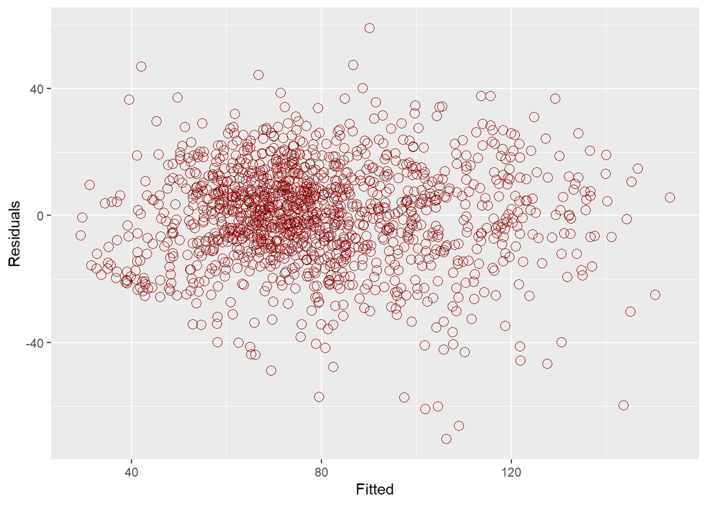

### Summary

```
##
## Call:
## lm(formula = maxO3 ~ T12 + Vx + Ne12 + maxO3v, data = ozone)
##
## Residuals:
##     Min      1Q  Median      3Q     Max
## -70.313  -9.129   0.935   9.953  58.950
##
## Coefficients:
##             Estimate Std. Error t value Pr(>|t|)
## (Intercept) 32.76618    2.87129  11.412  < 2e-16 ***
## T12          0.70387    0.10074   6.987 4.38e-12 ***
## Vx           0.93921    0.13449   6.983 4.50e-12 ***
## Ne12        -2.55848    0.22418 -11.413  < 2e-16 ***
## maxO3v       0.59597    0.01701  35.046  < 2e-16 ***
## ---
## Signif. codes:  0 '***' 0.001 '**' 0.01 '*' 0.05 '.' 0.1 ' ' 1
##
## Residual standard error: 15.68 on 1361 degrees of freedom
## Multiple R-squared:  0.6659, Adjusted R-squared:  0.6649
## F-statistic: 678.1 on 4 and 1361 DF,  p-value: < 2.2e-16
```

### Coefficients

```
## (Intercept)         T12          Vx        Ne12      maxO3v
##  32.7661837   0.7038747   0.9392082  -2.5584780   0.5959748
```

Les estimations des coefficients sont $\beta_0, \beta_1, \beta_2, \beta_3$ et $\beta_4$ sont respectivement $\beta_0=32.76618, \beta_1=0.70387$, $\beta_2=0.93921, \beta_3=-2.55848$ et $\beta_4=0.59597$. Le modele lineaire $\mathcal{M}_{2}$ est:

$$y=32.76618+0.70387 \,\, T12 + 0.93921
\,\, Vx -2.55848 \,\, Ne12 +0.59597 \,\, maxO3v.$$

### Residuals

```r
#Le residuals sont:

residuals_multiple <- res_multiple$residuals
#residuals_multiple
```

### Fitted Values

```r
#Le fitted values sont:

fitted_multiple <- res_multiple$fitted
#fitted_multiple
```

### The means

```
## The mean of the fitted values is 79.28141
```

```
## The mean of the residuals is 2.397328e-15
```

### $R^{2}$ squared et $R^{2}_{a}$ adjusted

```
##  Le R2 est value est 0.6658794
```

```
##  Le R2 adjusted value est 0.6648975
```

# Modèle lineaire avec tout les variables

On considere le modèle lineaire avec tout les variables explicatives

## Resume

### Summary

```
##
## Call:
## lm(formula = maxO3 ~ ., data = ozone)
##
## Residuals:
##     Min      1Q  Median      3Q     Max
## -66.664  -9.063   0.277   9.660  49.455
##
## Coefficients:
##              Estimate Std. Error t value Pr(>|t|)
## (Intercept)  41.20014   11.31132   3.642 0.000280 ***
## T6           -1.54951    0.28029  -5.528 3.88e-08 ***
## T9            0.10141    0.43054   0.236 0.813825
## T12           1.35109    0.40963   3.298 0.000998 ***
## T15           0.18992    0.42341   0.449 0.653831
## T18           0.15683    0.33125   0.473 0.635972
## Ne6          -0.09294    0.21773  -0.427 0.669545
## Ne9          -0.69359    0.31252  -2.219 0.026632 *
## Ne12         -0.84100    0.36079  -2.331 0.019900 *
## Ne15         -0.38348    0.34556  -1.110 0.267311
## Ne180       -15.79476   10.95285  -1.442 0.149516
## Ne181       -13.17350   10.83916  -1.215 0.224441
## Ne182       -12.00948   10.87340  -1.104 0.269581
## Ne183       -10.84205   10.86677  -0.998 0.318592
## Ne184       -12.95055   10.88617  -1.190 0.234400
## Ne185       -11.82442   10.84382  -1.090 0.275719
## Ne186       -13.48212   10.81210  -1.247 0.212634
## Ne187       -13.23046   10.78884  -1.226 0.220297
## Ne188       -13.92541   10.82302  -1.287 0.198439
## Vx            0.59868    0.14277   4.193 2.93e-05 ***
## maxO3v        0.58786    0.01667  35.266  < 2e-16 ***
## ---
## Signif. codes:  0 '***' 0.001 '**' 0.01 '*' 0.05 '.' 0.1 ' ' 1
##
## Residual standard error: 15.17 on 1345 degrees of freedom
## Multiple R-squared:  0.6909, Adjusted R-squared:  0.6863
## F-statistic: 150.3 on 20 and 1345 DF,  p-value: < 2.2e-16
```

```
##  Le R2 adjusted value est 0.6863159
```

# Analysis

$\textbf{Resume Modèle}$ $\mathcal{M}_{1}:$

1. Est-ce le modele $\mathcal{M}_{1}$ vous semple-t-il adapte et $\mathcal{M}_{2}$:
- Dans le modele de regression simple on a que $R^{2}_{\mathcal{M}_{1}}= 24\%$, on peut concluire que les modele n’est pas adapte, mais dans le modele de regression multiple on a que $R^{2}_{\mathcal{M}_{2}} = 66\%$ alors on peut concluire que le modele est meiller adapte, en plus, on n’observe pas de forme particulière avec le nuage des points. On montre que les variables ajoutées qui sont `V x`, `Ne12`, `maxO3v` contribue à mieux expliquer le modele.

$\textbf{Observation}:$ $R^2$ augmente avec chaque prédicteur ajouté à un modèle. Comme $R^2$ augmente toujours et ne diminue jamais, il peut sembler être un meilleur ajustement avec le plus de termes que vous ajoutez au modèle. Mais ce n’est pas toujours le meilleur choix.

# Intervalles de Confiance

Considérer maintenant le modèle $\mathrm{M}_2$. Calculer les intervalles de confiance pour chaque coefficient (créer une fonction si possible). Vous pouvez utiliser la fonction coef de la façon suivante pour récupérer directement les estimations des coefficients avec les statistiques et $df.residual pour récupérer directement les degrés de liberté nécéssaires dans le calcul des intervalles de confiance:

## Coefficiets

```
##               Estimate Std. Error    t value      Pr(>|t|)
## (Intercept) 32.7661837 2.87128787  11.411668  7.164360e-29
## T12          0.7038747 0.10073849   6.987147  4.377991e-12
## Vx           0.9392082 0.13449333   6.983307  4.495141e-12
## Ne12        -2.5584780 0.22417730 -11.412743  7.083953e-29
## maxO3v       0.5959748 0.01700557  35.045870 2.668762e-192
```

## Degres de liberte

```
## Les degres de liberte 1361
```

## Intervalles de Confiance avec confit

```
##                  2.5 %     97.5 %
## (Intercept) 27.1335537 38.3988136
## T12          0.5062551  0.9014943
## Vx           0.6753715  1.2030449
## Ne12        -2.9982486 -2.1187075
## maxO3v       0.5626149  0.6293348
```

## Intervalles de Confiance a la main

Cette fonction calcule l’intervalle de confiance

```r
#Hacer una funcion que calcule los intervalos de confianza.
#the estimae +-std.error *qt(0.96,degrefreedom )

# With alpha the significance level


conf_int <- function(model, alpha=0.05) {
  # Extract the coefficients and their standard errors from the model summary
  coef_summary <- summary(model)$coefficients
  coef_values <- coef_summary[, 1]
  coef_se <- coef_summary[, 2]

  # Compute the t-values for the given confidence level
  t_values <- qt(1 - alpha / 2, df = model$df.residual)

  # Compute the confidence intervals for each coefficient
  lower_bounds <- coef_values - t_values * coef_se
  upper_bounds <- coef_values + t_values * coef_se

  # Combine the lower and upper bounds into a matrix and add column names
  conf_int <- cbind(lower_bounds, upper_bounds)
  colnames(conf_int) <- c("Lower Bound", "Upper Bound")

  # Return the confidence intervals
  return(conf_int)
}


conf_int(res_multiple)
```

```
##             Lower Bound Upper Bound
## (Intercept)  27.1335537  38.3988136
## T12           0.5062551   0.9014943
## Vx            0.6753715   1.2030449
## Ne12         -2.9982486  -2.1187075
## maxO3v        0.5626149   0.6293348
```

Cette focntion ici, c’est l’intervalle de confiance avec R

```r
IC<-confint(res_multiple,level = 0.95)
IC
```

```
##                  2.5 %     97.5 %
## (Intercept) 27.1335537 38.3988136
## T12          0.5062551  0.9014943
## Vx           0.6753715  1.2030449
## Ne12        -2.9982486 -2.1187075
## maxO3v       0.5626149  0.6293348
```

## L’ellipse de confiance de 95%

Dessinez les ellipses de confiance (à 95%) des paramètres $\beta$ considérés deux à deux et sur chaque ellipse le rectangle de confiance construit à partir de chaque intervalle de confiance pris séparement.

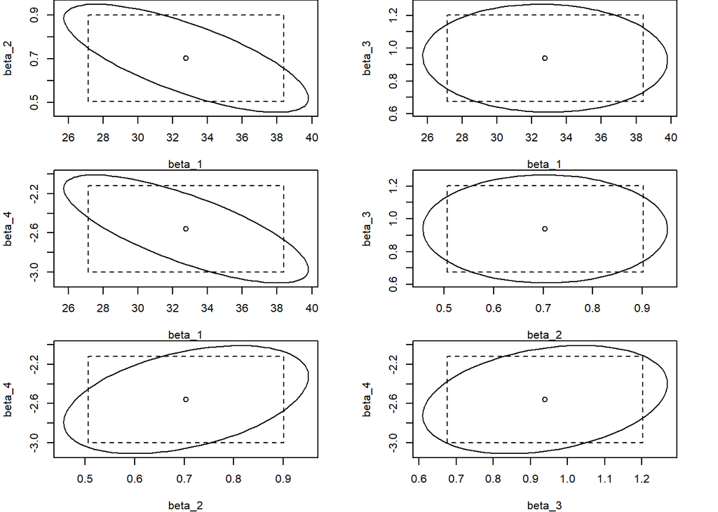

# Propriété de sans biais des estimateurs de coefficients $\beta_{j}$

Vérification de la propriété de sans biais des estimateurs de coefficients $\beta_j$ d’un modèle linéaire et calcul des taux de couverture

Nous allons tester dans cette section que les estimateurs de coefficients $\beta$ d’un modèle linéaire sont sans biais. En pratique, on ne peut jamais réaliser cela. On va simuler cela lors du TP. On considère pour cela que la table ozone est notre population d’étude, on connait donc les vraies valeurs des coefficients $\beta$ (cela n’est jamais possible en pratique car on n’a jamais la population d’étude). Dans cette population, nous allons tirer des échantillons aléatoires de taille $n=200$ et on va s’interesser à l’estimation du coefficient de la variable T12 qui est égal à:

# Echantionage

## Le valeur de `T12`

```
## Le vrai valeur de T12 est: 0.7038747
```

## Echantionage avec $n=200$ observations

```
##   [1] 1135  791  905 1341  807 1246 1311  292 1250  297  860  605  637 1063 1261
##  [16]  165  619 1057   83  866  277 1233 1023   76 1118 1054 1241  946 1199  374
##  [31]  323  115  850  608  682  938 1120  397 1172  989  392  593  744  243  106
##  [46]   11  625  386  403  461  141   31 1139   94   16  178  177  524  924  204
##  [61] 1338  373  646  384 1146  315  259  494 1072 1124 1016 1132   10  170  402
##  [76] 1345  108    8  626  261  541  326 1098  282 1307 1243  696  667  990 1143
##  [91]  452  856  622 1304 1060 1079 1264  891 1034  665 1129  793  463 1204  278
## [106]  241   24  679   37  686  566   19  378  549   48 1212  464  393 1163  670
## [121] 1213  311  189   38 1108  319 1257  846  120  712  441 1223  599   72  714
## [136]  677   81 1271  134  424  756    6 1152  879  668   49  193  709  459  303
## [151] 1328  898  190  191  446  119 1083  817   61 1295 1335  930  950  698  983
## [166]  758  993  947  690  251  560  643  545 1278  162  576  168  788   78 1267
## [181]  445  995   95  379  221 1280  620  448  242  927  814  926  407  229  785
## [196]  699 1047  218  648   79
```

## Valeur de `T12`

```
##
## Call:
## lm(formula = maxO3 ~ T12 + Vx + Ne12 + maxO3v, data = ozone.s)
##
## Coefficients:
## (Intercept)          T12           Vx         Ne12       maxO3v
##     40.4068       0.4622       1.3314      -2.6449       0.5804
```

```
##       T12
## 0.4621573
```

# Question 1

Considérer 10000 échantillons comme ci-dessus et calculer pour chaque échantillon l’estimation du coefficient de T12. Mettez ces estimations dans un vecteur de taille 10000.

$\textbf{Answer:}$

Ici nous montrons juste la première ligne du $10000$ et $20000$ echantillons.

## 10000 Echantillon avec $n=200$ observations

```r
nsim <- 10000
echantillon <- numeric(10000)
confinterval <- c()

for (i in 1:10000)
{
#sample with 200 observations
N <- nrow(ozone)
n <- 200
s <- sample(N,n)

ozone.s <- ozone[s,]
ozone.s

res2.s <- lm(maxO3 ~T12 + Vx + Ne12 +maxO3v, data=ozone.s)
rescof <- res2.s$coefficients[2]

## Interval de confiance
confinterval <- append(confinterval,confint(res2.s,level=0.95)[2,])


echantillon[i] <- rescof
}

head(echantillon)
```

```
## [1] 0.5049869 0.3758093 0.7963478 0.9651165 0.8457399 0.9183359
```

```r
#echantillon
```

## 20000 Echantillon avec $n=200$ observations

```
## [1] 0.7562587 0.7299679 0.4765873 0.5390277 0.5694816 1.0743406
```

## 10000 Echantillon avec $n=400$ observations

```
## [1] 0.6902926 0.7332076 0.8283719 0.9676027 0.4767603 0.8830131
```

## Function que depend de m nombre de simulation et r nombre des observations

```r
## n is the number of simulations:

echantillonvector <- function(m,r){

 nsim <- m
 echantillon <- numeric(m)
for (i in 1:m)
{
#sample with 200 observations
N <- nrow(ozone)
n <- r
s <- sample(N,n)

ozone.s <- ozone[s,]
ozone.s

res2.s <- lm(maxO3 ~T12 + Vx + Ne12 +maxO3v, data=ozone.s)
rescof <- res2.s$coefficients[2]

echantillon[i] <- rescof
}
return(echantillon)
}

echantillon3 <- echantillonvector(10000,400)
head(echantillon3)
```

```
## [1] 1.0135206 0.8473761 0.7595781 0.6837330 0.6804568 0.7997701
```

# Question 2

Calculer la moyenne de ces 10000 estimations et comparer avec la vrai valeur du coeffcient. Si ces deux valeurs sont très proches, on peut décider que l’estimateur est sans biais. Pour nous aider, on peut calculer le biais relatif de $\hat{\beta}$ :

$$RB(\hat{\beta})=\frac{\frac{1}{10000} \sum_{i=1}^{10000}
\hat{\beta}^{(i)}-\beta}{\beta},$$
où $\hat{\beta}^{(i)}$ est une estimation du paramètre $\beta$ à partir de ième échantillon et $\beta$ est la vraie valeur du paramètre.

On peut aussi représenter graphiquement la moyenne des estimations (voir figure plus bas). Attention, le calcul du biais relatif nous dit que la courbe est assez proche de la ligne en rouge qui est le vrai beta.

$\textbf{Answer:}$

a). La moyenne de ces 10000 et 20000 estimations:

## Le valeur de T12

```r
## Le vrai valeur de T12

cat("Le vrai valuer del coefficient correspondant a T12 est: ", T12)
```

```
## Le vrai valuer del coefficient correspondant a T12 est:  0.7038747
```

## Le means

```r
#10000
mean1 <- mean(echantillon)

cat("Le moyenne de 10000 echantillonage est ", mean1)
```

```
## Le moyenne de 10000 echantillonage est  0.6973428
```

```r
## 20000
mean2 <- mean(echantillon2)

cat("Le moyenne de 20000  est ", mean2)
```

```
## Le moyenne de 20000  est  0.6974637
```

```r
## 10000 avec n=400

mean3 <- mean(echantillon3)

cat("Le moyenne de 20000 echantillonage avec n=400 pbservations est ", mean3)
```

[output not shown]

$\textbf{Conclusion}$ Comme le vrai valeur et les valeurs de 10000 et 20000 echantionage sont tres proche, on peut concluire que le estimateur est sans biais.

## Le bias avec la focntion de R

b). Le biais relatif de $\hat{\beta}$ est different chaque fois:

```r
#biais del echantillon 10000
bi1 <- bias(echantillon, T12)
cat("Le bias de 10000 echantillonage avec n=200 avec R:",bi1 )
```

```
## Le bias de 10000 echantillonage avec n=200 avec R: -0.00653193
```

```r
#biais del echantillon 20000
bi2 <- bias(echantillon2, T12)
cat("Le bias de 20000 echantillonage avec n=200 avec R:",bi2 )
```

```
## Le bias de 20000 echantillonage avec n=200 avec R: -0.006410988
```

```r
#biais del echantillon 20000 avec n=400 observations

bi2 <- bias(echantillon3, T12)
cat("Le bias de 10000 echantillonage avec n=400 observations avec R:",bi2 )
```

```
## Le bias de 10000 echantillonage avec n=400 observations avec R: 0.0001750234
```

## Le bias a la main

```r
#EL VALOR MENOS EL DE ECHANTILLON
bia1 <- mean(echantillon) - T12
cat("Le bias de 10000 echantillonage avec n=200 est", bia1)
```

```
## Le bias de 10000 echantillonage avec n=200 est -0.00653193
```

```r
bia2 <- mean(echantillon2) - T12
cat("Le bias de 20000 echantillonage avec n=200", bia2)
```

```
## Le bias de 20000 echantillonage avec n=200 -0.006410988
```

```r
bia3 <- mean(echantillon3) - T12
cat("Le bias de 10000 echantillonage avec n=400 observations est", bia3)
```

```
## Le bias de 10000 echantillonage avec n=400 observations est 0.0001750234
```

## Graphe

c). Graphe moyenne en terms de nombre de simulations

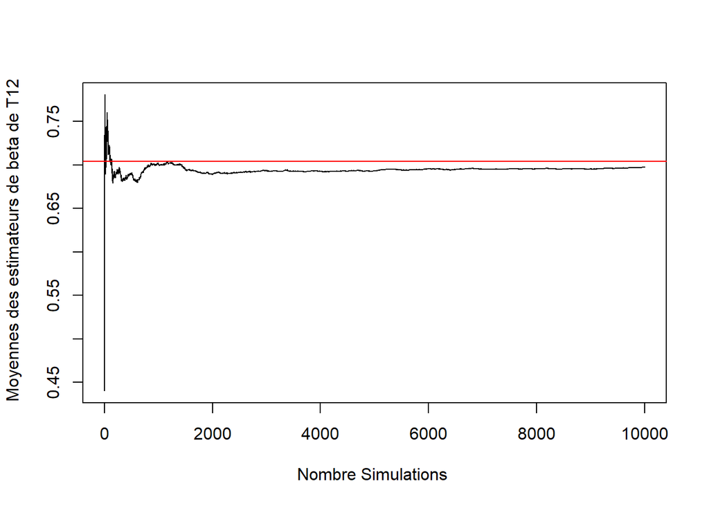

```r
# 10000 nombre de simulations avec n=200
plot( cumsum(echantillon)/(1:10000), type="l" ,xlab = "Nombre Simulations ", ylab = " Moyennes des estimateurs de beta de T12" )
abline(h=T12, col="red")
```

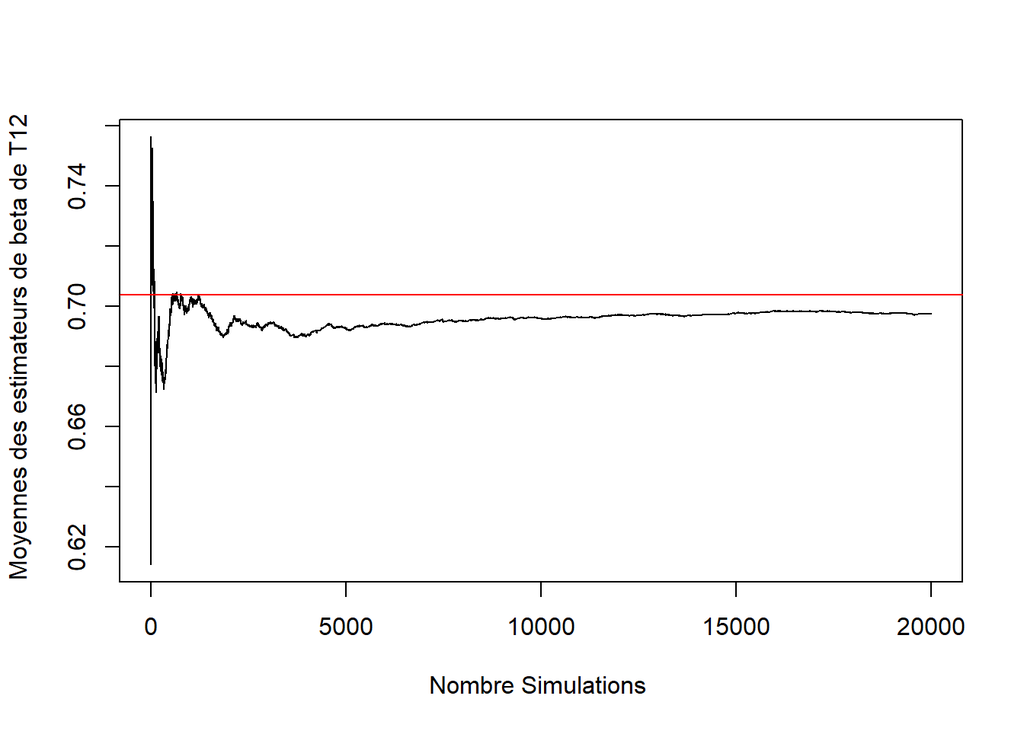

```r
# 20000 nombre de simulations avec n=200
plot( cumsum(echantillon2)/(1:20000), type="l" ,xlab = "Nombre Simulations ", ylab = " Moyennes des estimateurs de beta de T12" )
abline(h=T12, col="red")
```

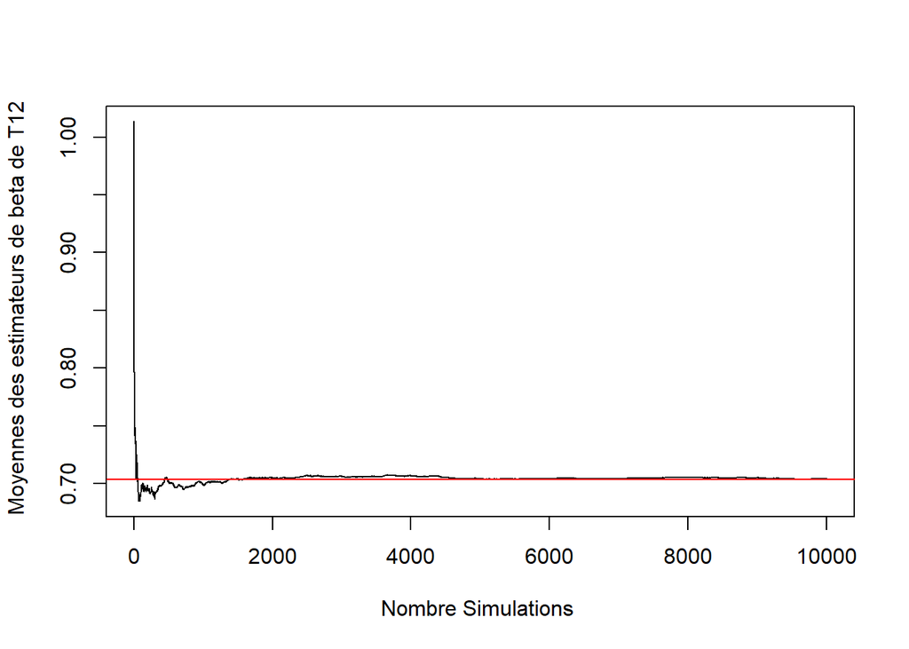

```r
# 10000 nombre de simulations avec n=400
plot( cumsum(echantillon3)/(1:10000), type="l" ,xlab = "Nombre Simulations ", ylab = " Moyennes des estimateurs de beta de T12" )
abline(h=T12, col="red")
```

# Question 3

3. On veut calculer maintenant le taux de couverture des intervalles de confiance de $\beta_{T 12}$. Il faut donc, pour chanque échantillon, regarder si $\beta_{T 12}$ appartient à l’intervalle de confiance construit à partir de cet échantillon et obtenir ensuite le taux de couverture (nombre d’échantillons qui contiennent $\beta_{T 12}$ divisé par 10000). Inspirez vous du point précédent pour calculer ce taux de couverture. Le mieux est de faire les deux calculs sur les mêmes échantillons (biais et taux de couverture).

$\textbf{Answer:}$

```r
beta <- T12

#echantillon
vecteurinter <- c()

#vecteurinter <- append(vecteurinter, confinterval[1] > beta && confinterval[2]>beta)
for (i in 1:10000){
  k=i-1
  vecteurinter <- append(vecteurinter, isTRUE(beta>confinterval[i+k] && beta<confinterval[i+k+1]))
  }

taux <- mean(vecteurinter)
cat("Le taux de couverture des intervalles de confiance de beta_{T 12} est:", taux)
```

```
## Le taux de couverture des intervalles de confiance de beta_{T 12} est: 0.9755
```

# Bootstrap

Le modèle utilisé est $Y=X \beta+\varepsilon$ où $\varepsilon$ est une variable aléatoire de loi $F$ inconnue et d’espérance nulle. L’idée du bootstrap est d’estimer cette loi par ré-échantillonnage.

On considere le modele suivante:

$$maxo3 = \beta_{0} + \beta_{1} T12 +
\beta_{2} Vx + \beta_{3} Ne12$$

```
##
## Call:
## lm(formula = maxO3 ~ T12 + Vx + Ne12, data = ozoneb)
##
## Residuals:
##     Min      1Q  Median      3Q     Max
## -75.461 -11.868   0.175  14.667  68.954
##
## Coefficients:
##             Estimate Std. Error t value Pr(>|t|)
## (Intercept)  67.4299     3.7166  18.143  < 2e-16 ***
## T12           1.6163     0.1342  12.046  < 2e-16 ***
## Vx            1.3979     0.1846   7.574 6.63e-14 ***
## Ne12         -3.4475     0.3071 -11.226  < 2e-16 ***
## ---
## Signif. codes:  0 '***' 0.001 '**' 0.01 '*' 0.05 '.' 0.1 ' ' 1
##
## Residual standard error: 21.62 on 1362 degrees of freedom
## Multiple R-squared:  0.3644, Adjusted R-squared:  0.363
## F-statistic: 260.2 on 3 and 1362 DF,  p-value: < 2.2e-16
```

## Les residus estimés

On calcule les residus estimes $\hat{\epsilon} = \hat{Y} -Y$ et ajustements $\hat{Y}$.

```r
res<-residuals(modele3)
y_chapeau <-predict(modele3)
COEFF <-matrix(0, ncol = 4,nrow = 10000)
colnames(COEFF) <-names(coef(modele3))
ozone.boot<-ozoneb
```

On applique la methode de bootstrap avec 10000 ($dim(COEF)$) echantillons bootstrapes:

```r
for (i in 1:nrow(COEFF)){
Regetoile <- sample(res,length(res),replace=T)
mod_etoile<-y_chapeau + Regetoile
ozone.boot[,"T12"] <-mod_etoile
modele3boot<-lm(formula(modele3),data = ozone.boot)
COEFF[i,] <-coef(modele3boot) # On obtient une matrice de 1000 coefficients estimés
}
```

## Confidence Interval

Nous avons obtenu un matrice de 10000 coefficients estimés (`COEF`) et nous choisir les quantiles empiriques a $2.5\%$ et $97.5\%$.

```
##       (Intercept)        T12       Vx      Ne12
## 2.5%     92.48188 0.04563539 1.231091 -4.977863
## 97.5%   103.37990 0.14635306 1.394780 -4.437713
```

## Histogram

Cette histogramme semble indiquer que la loi est proche d’une loi normale.

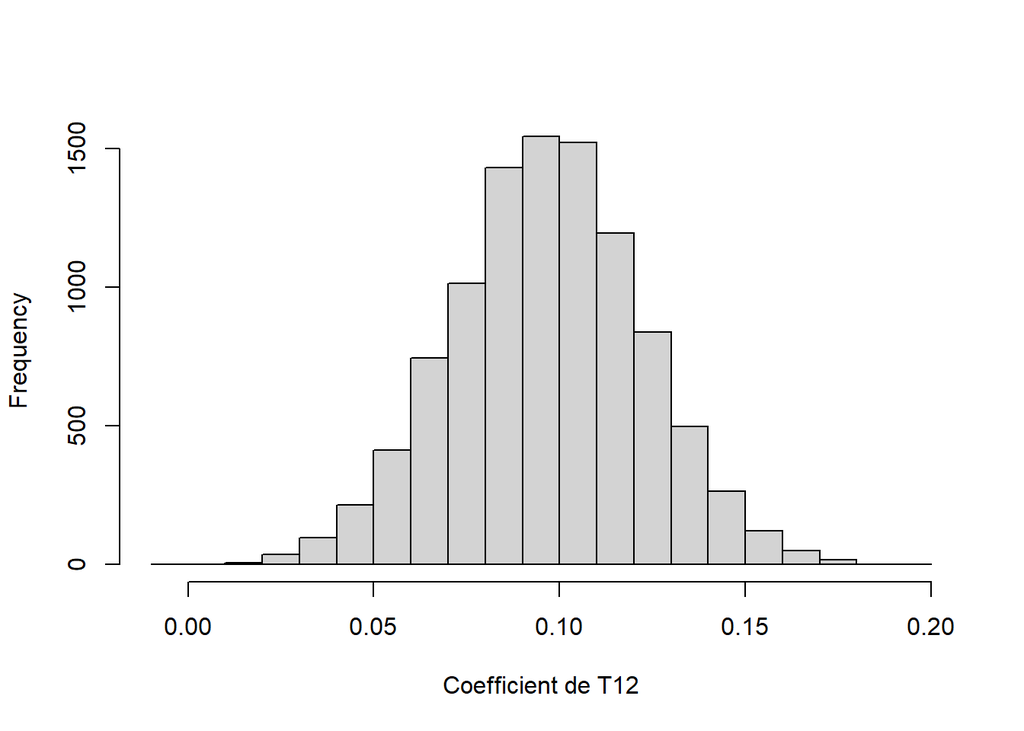

```r
hist(COEFF[,"T12"],main="",xlab="Coefficient de T12")
```